# Section 3: Poisson Regression

Pablo Arés Gastesi

2026-07-06

# 1 Why Not Linear Regression for Count Data?

The response variable in many real problems is a **count**: number of accidents on a road in a month, number of insurance claims per customer per year, number of words produced in a speech, number of defects per metre of cable. Count variables have two features that make ordinary linear regression inappropriate:

- They are **non-negative integers**. A linear model can predict negative values, which are meaningless for counts.
- Their **variance grows with their mean**. In a linear model, variance is assumed constant (homoscedasticity). For counts, larger expected values typically come with larger spread.

The natural model for count data is **Poisson regression**, a special case of the Generalised Linear Model (GLM) framework.

# 2 The Poisson Distribution

Recall that the Poisson distribution models the number of events occurring in a fixed interval of time or space, given a constant average rate. Its probability mass function is

$$P(X = k) = \frac{e^{-\lambda}\lambda^k}{k!}, \quad k = 0, 1, 2, \ldots$$

where $\lambda > 0$ is the **rate parameter**. A key property is that the mean and variance are both equal to $\lambda$:

$$\mathbb{E}[X] = \text{Var}(X) = \lambda.$$

The rate $\lambda$ is scalable: if $\lambda$ is the number of defects per metre of cable, then for two metres the expected count is $2\lambda$.

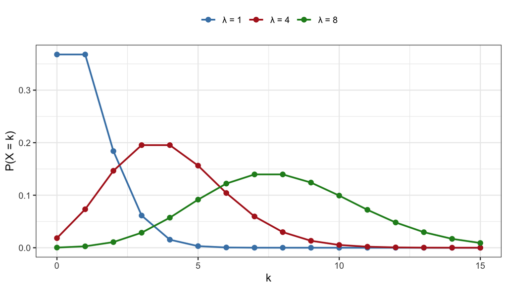

Figure 2.1: Poisson probability mass function for three values of the rate parameter.

```r
x <- 0:15
df_pois <- data.frame(
  k      = rep(x, 3),
  prob   = c(dpois(x, 1), dpois(x, 4), dpois(x, 8)),
  lambda = rep(c("λ = 1", "λ = 4", "λ = 8"), each = length(x))
)

ggplot(df_pois, aes(x = k, y = prob, colour = lambda)) +
  geom_line(linewidth = 0.8) +
  geom_point(size = 2) +
  scale_colour_manual(values = c("λ = 1" = "steelblue",
                                 "λ = 4" = "firebrick",
                                 "λ = 8" = "forestgreen")) +
  labs(x = "k", y = "P(X = k)", colour = NULL) +
  theme_bw() +
  theme(legend.position = "top")
```

As $\lambda$ increases, the distribution shifts right and becomes more symmetric, eventually resembling a normal distribution. This follows from the additive property of the Poisson: a Poisson($\lambda$) variable can be written as the sum of $\lambda$ independent Poisson(1) variables, so by the CLT that sum converges to a normal as $\lambda \to \infty$. More precisely, $(X - \lambda)/\sqrt{\lambda} \xrightarrow{d} \mathcal{N}(0,1)$, a useful approximation when $\lambda \gtrsim 10$.

# 3 The Poisson Regression Model

## 3.1 Model Specification

Poisson regression is a GLM with:

- **Random component**: $Y_i \sim \text{Poisson}(\lambda_i)$
- **Systematic component**: a linear predictor $\eta_i = \mathbf{x}_i^\top \boldsymbol{\beta}$
- **Link function**: the natural logarithm, $\ln(\lambda_i) = \eta_i$

Equivalently:

$$\ln(\mathbb{E}[Y_i \mid \mathbf{x}_i]) = \beta_0 + \beta_1 x_{i1} + \cdots + \beta_p x_{ip}$$

or, exponentiating both sides:

$$\mathbb{E}[Y_i \mid \mathbf{x}_i] = e^{\beta_0 + \beta_1 x_{i1} + \cdots + \beta_p x_{ip}}.$$

The log link ensures that fitted values are always positive, solving the main problem with using a linear model for counts.

## 3.2 Interpreting Coefficients

Because of the log link, coefficients are not interpreted additively as in linear regression. For a unit increase in $x_j$, the expected count is **multiplied** by $e^{\beta_j}$, holding all other variables fixed.

- $\beta_j > 0$: the expected count **increases** with $x_j$ (since $e^{\beta_j} > 1$).
- $\beta_j < 0$: the expected count **decreases** with $x_j$ (since $e^{\beta_j} < 1$).
- $\beta_j = 0$: $x_j$ has no effect on the expected count.

The quantity $e^{\beta_j}$ is known as the **incidence rate ratio** (IRR).

## 3.3 Fitting in R

Poisson regression is fitted with `glm()` using `family = poisson`:

```r
glm(y ~ x1 + x2, family = poisson, data = mydata)
```

The default link for `family = poisson` is the log link. Parameters are estimated by maximum likelihood via iteratively reweighted least squares (IWLS).

# 4 Example 1: Yarn Breaks

The `warpbreaks` dataset (built into R) records the number of warp breaks per loom in a weaving experiment. There are two factors: type of wool (`A` or `B`) and level of tension (`L`, `M`, `H`).

```r
data(warpbreaks)
str(warpbreaks)
```

```
## 'data.frame':    54 obs. of  3 variables:
##  $ breaks : num  26 30 54 25 70 52 51 26 67 18 ...
##  $ wool   : Factor w/ 2 levels "A","B": 1 1 1 1 1 1 1 1 1 1 ...
##  $ tension: Factor w/ 3 levels "L","M","H": 1 1 1 1 1 1 1 1 1 2 ...
```

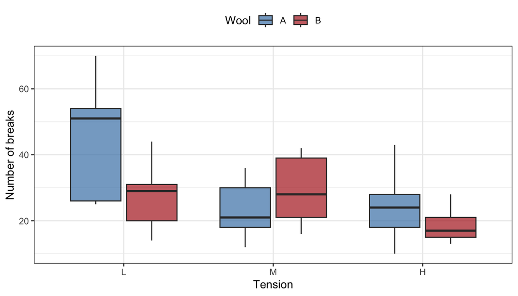

Figure 4.1: Distribution of warp breaks by wool type and tension level.

```r
ggplot(warpbreaks, aes(x = tension, y = breaks, fill = wool)) +
  geom_boxplot(alpha = 0.7) +
  scale_fill_manual(values = c("A" = "steelblue", "B" = "firebrick")) +
  labs(x = "Tension", y = "Number of breaks", fill = "Wool") +
  theme_bw() +
  theme(legend.position = "top")
```

```r
# Check mean vs variance by group (Poisson assumption: mean ≈ variance)
aggregate(breaks ~ wool + tension, data = warpbreaks,
          FUN = function(x) round(c(mean = mean(x), var = var(x)), 2))
```

[output not shown]

## 4.1 Fitting the Model

```r
m1 <- glm(breaks ~ wool + tension, family = poisson, data = warpbreaks)
summary(m1)
```

```
##
## Call:
## glm(formula = breaks ~ wool + tension, family = poisson, data = warpbreaks)
##
## Coefficients:
##             Estimate Std. Error z value Pr(>|z|)
## (Intercept)  3.69196    0.04541  81.302  < 2e-16 ***
## woolB       -0.20599    0.05157  -3.994 6.49e-05 ***
## tensionM    -0.32132    0.06027  -5.332 9.73e-08 ***
## tensionH    -0.51849    0.06396  -8.107 5.21e-16 ***
## ---
## Signif. codes:  0 '***' 0.001 '**' 0.01 '*' 0.05 '.' 0.1 ' ' 1
##
## (Dispersion parameter for poisson family taken to be 1)
##
##     Null deviance: 297.37  on 53  degrees of freedom
## Residual deviance: 210.39  on 50  degrees of freedom
## AIC: 493.06
##
## Number of Fisher Scoring iterations: 4
```

## 4.2 Interpreting the Output

The reference levels are wool `A` and tension `L`. The coefficient for `woolB` is negative, meaning wool B has fewer expected breaks than wool A, all else equal. The coefficients for tension `M` and `H` are also negative, meaning higher tension leads to fewer breaks than low tension.

To get the incidence rate ratios:

```r
round(exp(coef(m1)), 3)
```

```
## (Intercept)       woolB    tensionM    tensionH
##      40.124       0.814       0.725       0.595
```

So, for example, switching from tension `L` to tension `H` multiplies the expected number of breaks by 0.595 — a reduction of about 40%.

## 4.3 Confidence Intervals

Confidence intervals on the IRR scale are obtained by exponentiating the coefficient confidence intervals:

```r
round(exp(confint(m1)), 3)
```

```
##              2.5 % 97.5 %
## (Intercept) 36.668 43.814
## woolB        0.735  0.900
## tensionM     0.644  0.816
## tensionH     0.525  0.675
```

## 4.4 Predicted Values

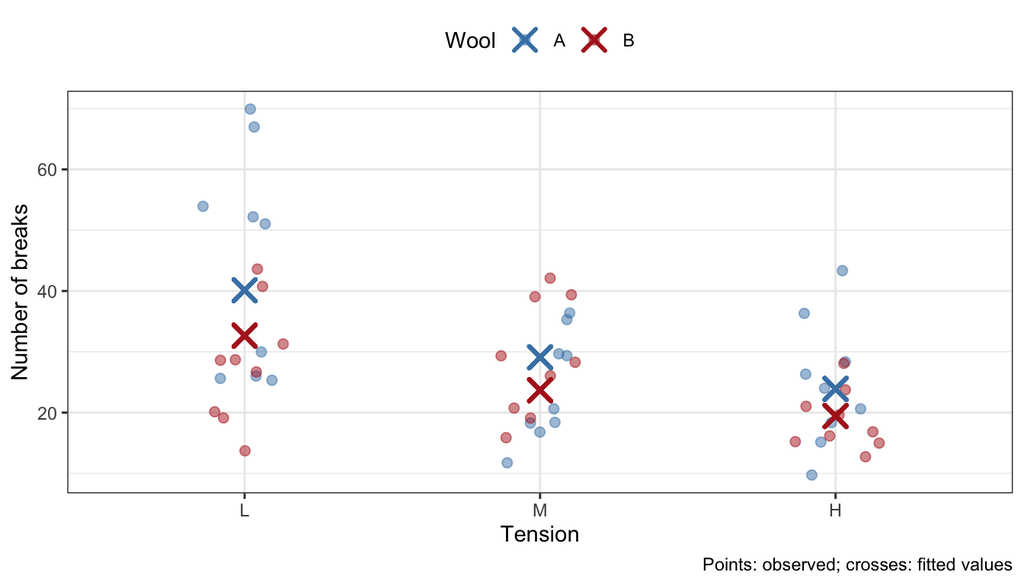

Figure 4.2: Observed counts (points, jittered) and model predictions (crosses) by wool type and tension.

```r
warpbreaks$fitted <- fitted(m1)

ggplot(warpbreaks, aes(x = tension, colour = wool)) +
  geom_jitter(aes(y = breaks), width = 0.15, alpha = 0.5, size = 2) +
  geom_point(aes(y = fitted), shape = 4, size = 4, stroke = 1.5) +
  scale_colour_manual(values = c("A" = "steelblue", "B" = "firebrick")) +
  labs(x = "Tension", y = "Number of breaks",
       colour = "Wool",
       caption = "Points: observed; crosses: fitted values") +
  theme_bw() +
  theme(legend.position = "top")
```

# 5 Model Evaluation

## 5.1 Deviance and Pseudo-$R^2$

Unlike linear regression, there is no single universally agreed $R^2$ for GLMs. The most common measure is **McFadden’s pseudo-$R^2$**:

$$R^2_{\text{McFadden}} = 1 - \frac{\ell(\hat{\boldsymbol{\beta}})}{\ell(\hat{\beta}_0)}$$

where $\ell(\hat{\boldsymbol{\beta}})$ is the log-likelihood of the fitted model and $\ell(\hat{\beta}_0)$ is the log-likelihood of the null model (intercept only). Equivalently, using deviances:

$$R^2_{\text{McFadden}} = 1 - \frac{\text{Residual deviance}}{\text{Null deviance}}.$$

Values between 0.2 and 0.4 are generally considered a good fit for count models (the scale is different from the linear $R^2$, which can reach 1 for a perfect fit). A value of 1 would indicate a perfect fit; 0 means the predictors add nothing over the intercept.

```r
pseudo_r2 <- 1 - m1$deviance / m1$null.deviance
cat(sprintf("Pseudo R² (McFadden) = %.3f\n", pseudo_r2))
```

```
## Pseudo R² (McFadden) = 0.292
```

```r
cat(sprintf("AIC = %.1f\n", AIC(m1)))
```

```
## AIC = 493.1
```

## 5.2 Residual Diagnostics

For Poisson GLMs, **Pearson residuals** and **deviance residuals** are the standard diagnostic tools. A plot of residuals against fitted values should show no clear pattern.

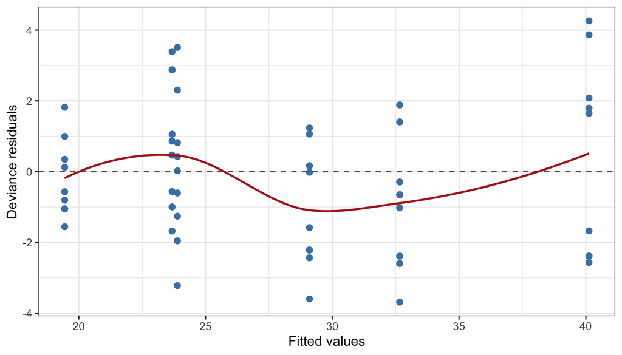

Figure 5.1: Deviance residuals vs fitted values for the warpbreaks Poisson model. No strong pattern is ideal.

```r
df_resid <- data.frame(
  fitted    = fitted(m1),
  residuals = residuals(m1, type = "deviance")
)

ggplot(df_resid, aes(x = fitted, y = residuals)) +
  geom_point(colour = "steelblue", size = 2) +
  geom_hline(yintercept = 0, linetype = "dashed", colour = "grey40") +
  geom_smooth(method = "loess", se = FALSE, colour = "firebrick",
              linewidth = 0.8) +
  labs(x = "Fitted values", y = "Deviance residuals") +
  theme_bw()
```

# 6 Overdispersion

## 6.1 What is Overdispersion?

A key assumption of the Poisson model is that $\text{Var}(Y) = \mathbb{E}[Y] = \lambda$. In practice, count data often exhibit **overdispersion**: the observed variance exceeds the mean. This can happen due to:

- Omitted explanatory variables
- Clustering or correlation in the data
- Excess zeros (more zero counts than a Poisson model predicts)

Fitting a Poisson model to overdispersed data gives **correct point estimates** for the coefficients but **standard errors that are too small** — leading to confidence intervals that are too narrow and p-values that are too small.

## 6.2 Detecting Overdispersion

A quick check is to compare the residual deviance to its degrees of freedom. Under a correctly specified Poisson model, the ratio should be close to 1. A ratio substantially above 1 signals overdispersion.

```r
dispersion_ratio <- m1$deviance / m1$df.residual
cat(sprintf("Residual deviance / df = %.2f\n", dispersion_ratio))
```

```
## Residual deviance / df = 4.21
```

## 6.3 Dealing with Overdispersion

Two common approaches:

**1. Quasi-Poisson**: replaces the Poisson variance assumption with $\text{Var}(Y_i) = \phi \cdot \lambda_i$, where $\phi$ is an estimated **dispersion parameter**. Coefficients are unchanged; standard errors are scaled by $\sqrt{\hat{\phi}}$.

```r
m1_quasi <- glm(breaks ~ wool + tension, family = quasipoisson, data = warpbreaks)
summary(m1_quasi)$coefficients
```

```
##               Estimate Std. Error   t value     Pr(>|t|)
## (Intercept)  3.6919631 0.09374352 39.383662 2.635587e-39
## woolB       -0.2059884 0.10646089 -1.934874 5.867292e-02
## tensionM    -0.3213204 0.12440965 -2.582761 1.277482e-02
## tensionH    -0.5184885 0.13203462 -3.926913 2.639908e-04
```

**2. Negative Binomial regression**: uses a different distributional family that explicitly models overdispersion. Available via `MASS::glm.nb()`.

```r
library(MASS)
m1_nb <- glm.nb(breaks ~ wool + tension, data = warpbreaks)
summary(m1_nb)$coefficients
```

```
##               Estimate Std. Error   z value      Pr(>|z|)
## (Intercept)  3.6733546 0.09790305 37.520329 4.294231e-308
## woolB       -0.1862111 0.10096140 -1.844379  6.512797e-02
## tensionM    -0.2992272 0.12172850 -2.458153  1.396538e-02
## tensionH    -0.5113955 0.12373986 -4.132828  3.583277e-05
```

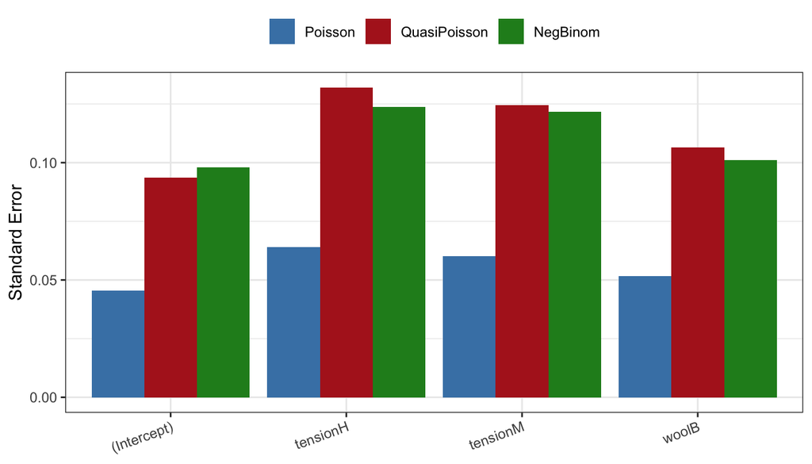

Figure 6.1: Standard errors from Poisson, quasi-Poisson, and negative binomial models. Overdispersion correction inflates the SEs.

```r
df_se <- data.frame(
  term  = names(coef(m1)),
  Poisson  = summary(m1)$coefficients[, 2],
  QuasiPoisson = summary(m1_quasi)$coefficients[, 2],
  NegBinom = summary(m1_nb)$coefficients[, 2]
)

df_se_long <- reshape2::melt(df_se, id.vars = "term",
                              variable.name = "Model", value.name = "SE")

ggplot(df_se_long, aes(x = term, y = SE, fill = Model)) +
  geom_col(position = "dodge") +
  scale_fill_manual(values = c("Poisson"      = "steelblue",
                               "QuasiPoisson" = "firebrick",
                               "NegBinom"     = "forestgreen")) +
  labs(x = NULL, y = "Standard Error", fill = NULL) +
  theme_bw() +
  theme(legend.position = "top",
        axis.text.x = element_text(angle = 20, hjust = 1))
```

Figure 6.1 shows that accounting for overdispersion increases the standard errors — making inference more conservative and honest.

# 7 Example 2: Simulated Count Data

To illustrate coefficient interpretation clearly, we simulate a simple dataset where the true data-generating process is known.

```r
set.seed(42)
n  <- 200
x1 <- rnorm(n, mean = 5, sd = 2)          # continuous predictor
x2 <- rbinom(n, size = 1, prob = 0.5)     # binary predictor

# True model: log(lambda) = 0.3 + 0.2*x1 + 0.5*x2
log_lambda <- 0.3 + 0.2 * x1 + 0.5 * x2
y <- rpois(n, lambda = exp(log_lambda))

sim_data <- data.frame(y, x1, x2 = factor(x2, labels = c("Group 0", "Group 1")))
```

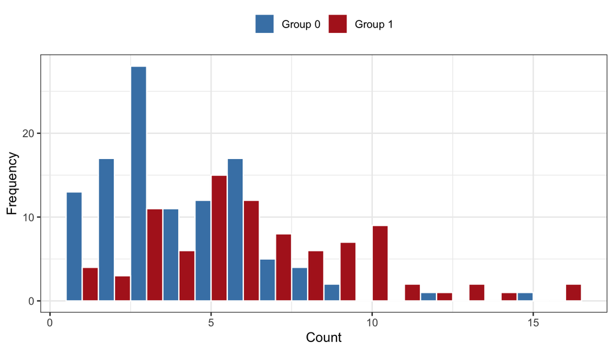

Figure 7.1: Distribution of simulated counts by group.

```r
ggplot(sim_data, aes(x = y, fill = x2)) +
  geom_histogram(binwidth = 1, position = "dodge", colour = "white") +
  scale_fill_manual(values = c("Group 0" = "steelblue", "Group 1" = "firebrick")) +
  labs(x = "Count", y = "Frequency", fill = NULL) +
  theme_bw() +
  theme(legend.position = "top")
```

```r
m2 <- glm(y ~ x1 + x2, family = poisson, data = sim_data)
summary(m2)
```

```
##
## Call:
## glm(formula = y ~ x1 + x2, family = poisson, data = sim_data)
##
## Coefficients:
##             Estimate Std. Error z value Pr(>|z|)
## (Intercept)  0.41982    0.10394   4.039 5.37e-05 ***
## x1           0.18635    0.01654  11.266  < 2e-16 ***
## x2Group 1    0.45286    0.06294   7.195 6.25e-13 ***
## ---
## Signif. codes:  0 '***' 0.001 '**' 0.01 '*' 0.05 '.' 0.1 ' ' 1
##
## (Dispersion parameter for poisson family taken to be 1)
##
##     Null deviance: 351.93  on 199  degrees of freedom
## Residual deviance: 165.78  on 197  degrees of freedom
## AIC: 837.36
##
## Number of Fisher Scoring iterations: 4
```

The estimated coefficients should be close to the true values (0.3, 0.2, 0.5). The IRRs are:

```r
cbind(
  IRR    = round(exp(coef(m2)), 3),
  `2.5%` = round(exp(confint(m2)[, 1]), 3),
  `97.5%`= round(exp(confint(m2)[, 2]), 3)
)
```

```
##               IRR  2.5% 97.5%
## (Intercept) 1.522 1.239 1.862
## x1          1.205 1.166 1.245
## x2Group 1   1.573 1.391 1.780
```

Interpreting the IRR for `x1`: a one-unit increase in `x1` multiplies the expected count by approximately 1.2, holding `x2` fixed. Group 1 has an expected count roughly 1.57 times that of Group 0.

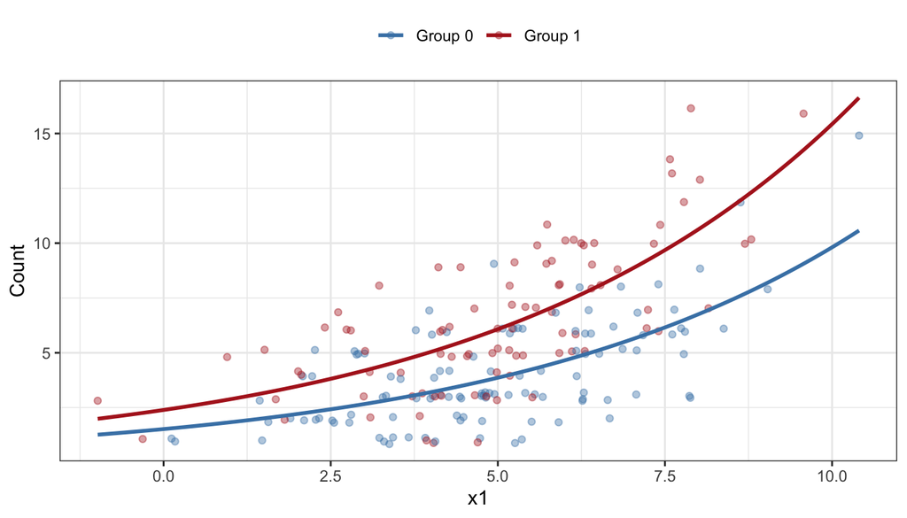

Figure 7.2: Observed counts and Poisson model predictions as a function of x1, by group.

```r
x1_seq <- seq(min(x1), max(x1), length.out = 100)
df_pred <- rbind(
  data.frame(x1 = x1_seq, x2 = factor("Group 0"),
             fitted = predict(m2, newdata = data.frame(x1 = x1_seq, x2 = factor("Group 0", levels = c("Group 0","Group 1"))), type = "response")),
  data.frame(x1 = x1_seq, x2 = factor("Group 1"),
             fitted = predict(m2, newdata = data.frame(x1 = x1_seq, x2 = factor("Group 1", levels = c("Group 0","Group 1"))), type = "response"))
)

ggplot() +
  geom_jitter(data = sim_data, aes(x = x1, y = y, colour = x2),
              alpha = 0.4, height = 0.2) +
  geom_line(data = df_pred, aes(x = x1, y = fitted, colour = x2),
            linewidth = 1) +
  scale_colour_manual(values = c("Group 0" = "steelblue",
                                 "Group 1" = "firebrick")) +
  labs(x = "x1", y = "Count", colour = NULL) +
  theme_bw() +
  theme(legend.position = "top")
```

# 8 Offset Terms

Sometimes the **exposure** varies across observations: number of accidents per road varies with road length; number of crimes per neighbourhood varies with population. In these cases we model the *rate* rather than the raw count by including an **offset** term — a predictor with a fixed coefficient of 1:

$$\ln(\lambda_i) = \ln(t_i) + \beta_0 + \beta_1 x_{i1} + \cdots$$

where $t_i$ is the exposure for observation $i$. In R:

```r
glm(count ~ x1 + x2 + offset(log(exposure)),
    family = poisson, data = mydata)
```

Without an offset, comparing counts across observations with different exposures would be misleading — like comparing total rainfall in two cities without accounting for the fact that one has twice as many rainy days.

# 9 Summary

| Aspect | Detail |
| --- | --- |
| Response variable | Non-negative integer counts |
| Distribution | Poisson($\lambda_i$) |
| Link function | $\ln(\lambda_i) = \mathbf{x}_i^\top \boldsymbol{\beta}$ |
| Coefficient interpretation | $e^{\beta_j}$ = multiplicative change in expected count (IRR) |
| Estimation | Maximum likelihood (IWLS) |
| Goodness of fit | Pseudo-$R^2$, AIC, residual deviance / df |
| Overdispersion | Check deviance/df $\gg 1$; use quasi-Poisson or negative binomial |
| Varying exposure | Include `offset(log(exposure))` |

# 10 References

- McCullagh, P. & Nelder, J. A. (1989). *Generalized Linear Models* (2nd ed.). Chapman & Hall.
- Agresti, A. (2015). *Foundations of Linear and Generalized Linear Models*. Wiley.
- Venables, W. N. & Ripley, B. D. (2002). *Modern Applied Statistics with S* (4th ed.). Springer. (The `MASS` package.)
- James, G., Witten, D., Hastie, T., & Tibshirani, R. (2023). *An Introduction to Statistical Learning with Applications in R* (2nd ed.). Springer.
- UCLA, Advanced Research Computing, *Poisson Regression. R Data Analysis Examples. Available at [this link](https://stats.oarc.ucla.edu/r/dae/poisson-regression/)
- Wikipedia, *Poisson Regression*. Available at [this link](https://en.wikipedia.org/wiki/Poisson_regression)